# Seurat Analysis of HNSCC data set

##LIBRARIES Load the libraries:

```r
library(limma)
library(dplyr)
library(Seurat)
library(patchwork)
```

##DATASET Load the data set:

```r
hnscc_data <- read.table(file='/home/ressf/Documenti/RessBachelorsThesisCode/Downstream_analysis/HNSCC/HNSCC_all_data.txt' , row.names=1, skip=6, sep='\t')
```

Create a Seurat Object:

```r
hnscc <- CreateSeuratObject(counts=hnscc_data)
```

Print the object to make sure everything is ok:

```r
print(hnscc)
```

```
## An object of class Seurat
## 23686 features across 5902 samples within 1 assay
## Active assay: RNA (23686 features, 0 variable features)
```

Violin plot of the data:

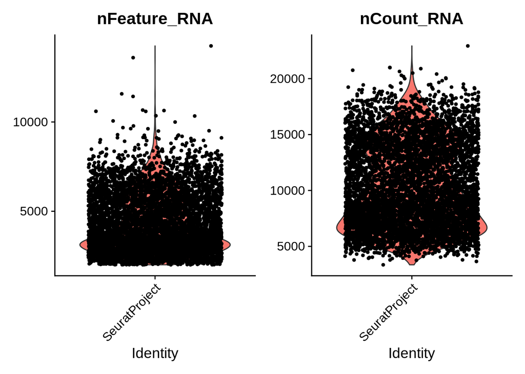

```r
VlnPlot(hnscc, features=c("nFeature_RNA","nCount_RNA"),ncol=2)
```

Calculate percentage.mt and plot it:

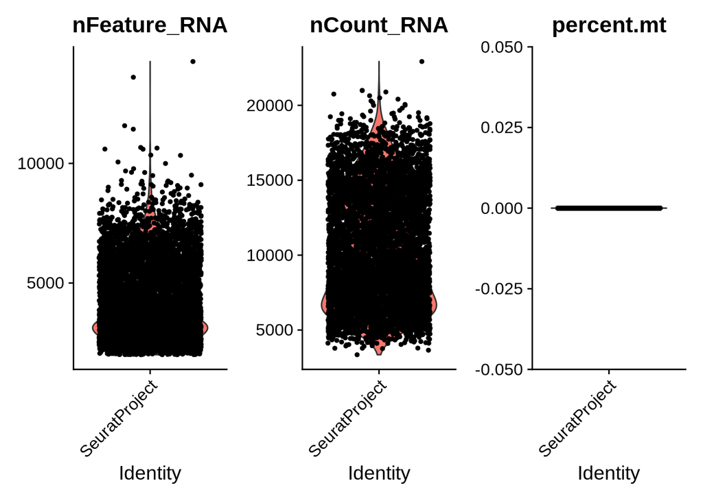

```r
hnscc[["percent.mt"]] <- PercentageFeatureSet(hnscc, pattern = "^MT-")
VlnPlot(hnscc, features=c("nFeature_RNA","nCount_RNA","percent.mt"),ncol=3)
```

##Normalization Normalize the Data:

```r
#normalization
hnscc_norm <- NormalizeData(hnscc, normalization.method="LogNormalize", scale.factor=10000)
```

#Feature selection The data was normalized, we proceed:

```r
#feature selection
hnscc_norm <- FindVariableFeatures(hnscc_norm, selection.method="vst", nfeatures= 5902)
```

```r
top10 <- head(VariableFeatures(hnscc_norm), 10)
plot1 <-VariableFeaturePlot(hnscc_norm)
plot2 <-LabelPoints(plot= plot1, points=top10, repel =TRUE)
```

```
## When using repel, set xnudge and ynudge to 0 for optimal results
```

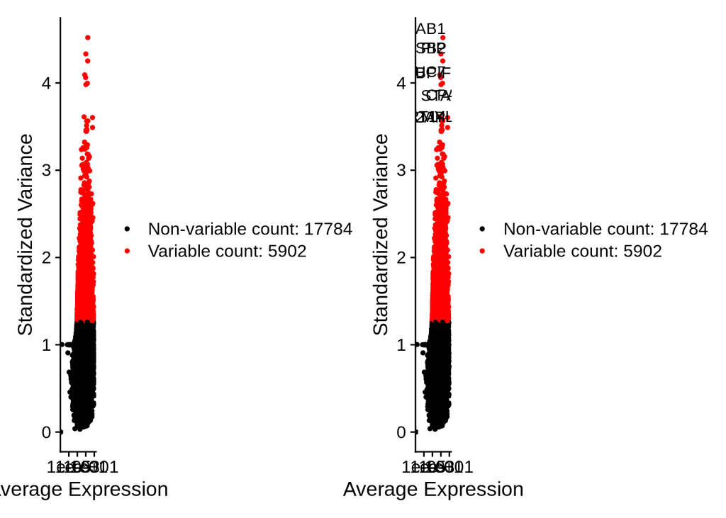

```r
plot1+plot2
```

Find Variable Features of the data:

```r
hnsccFeatures <- FindVariableFeatures(hnscc, selection.method="vst", nfeatures=5902)
```

#Scaling and PCA Scaling the data:

```r
# scaling the data
all.genes <-rownames(hnsccFeatures)
hnsccScaled<-ScaleData(hnscc_norm,features=all.genes)
```

Perform PCA:

```r
#perform linear dimensional reduction
hnsccScaled<- RunPCA (hnsccScaled, features = VariableFeatures(object=hnsccScaled))
```

```
## PC_ 1
## Positive:  SRGN, PTPRC, RGS1, CXCR4, LAPTM5, CD3G, TSC22D3, IL2RG, CD2, LCP1
##     NR4A2, IFITM2, SAMSN1, CD3E, CD53, ZNF331, CD52, CD3D, CD96, CYTIP
##     FYN, LCK, TNFAIP3, ARHGDIB, DUSP4, VIM, SLA, PIM2, SEPT1, S100A4
## Negative:  KRT5, FXYD3, KRT17, KRT6A, SFN, SERPINB5, JUP, TACSTD2, CALML3, CLCA2
##     KRT14, PERP, S100A16, SPINT2, CDH3, LAMB3, IFI27, MAGEA4, S100A2, LYPD3
##     LGALS7, KRT6C, RBP1, KRT18, SLC7A8, LGALS7B, KLK8, SLC2A1, TM4SF1, ANXA8L1
## PC_ 2
## Positive:  CNN3, SERPING1, SPARC, LHFP, MYL9, BGN, EBF1, SPARCL1, COL1A2, IGFBP7
##     A2M, PDGFRB, C1R, COL6A2, NNMT, CRISPLD2, COL3A1, AEBP1, PCOLCE, MGP
##     FN1, DCN, COL1A1, ISLR, COL6A1, CYR61, TAGLN, ADAMTS1, TIMP3, COL14A1
## Negative:  PTPRC, RGS1, LCP1, IL2RG, CXCR4, ARHGDIB, CD2, SRGN, LAPTM5, CORO1A
##     CD3G, CD3E, SAMSN1, CD53, CD3D, LCK, CYTIP, FYB, CD52, SLA
##     RAC2, CD96, DUSP4, SEPT1, CD7, VAMP8, CD74, CD69, SELPLG, GPR183
## PC_ 3
## Positive:  HLA-DRA, CD74, HLA-DRB1, S100A9, S100A8, SLC31A2, AIF1, HLA-DPA1, IGSF6, CA2
##     C1QB, C1QA, IFI30, PRSS23, MS4A6A, TYROBP, MS4A4A, HLA-DQB1, CD14, RNASE1
##     CD163, FCGR3A, MRC1, SLCO2B1, C1QC, TSPAN4, HLA-DMB, CTSH, CPVL, HLA-DMA
## Negative:  MYH11, CYP4F11, GSTA1, FGFBP2, CYP4F3, OSGIN1, UGT1A6, UGT1A7, CT45A1, LOC344887
##     C1orf110, CT45A3, CES1, GPX2, UCHL1, ADH7, KLK6, EPCAM, UGT1A10, SUSD4
##     EPS8, ALDH3A1, AGPAT9, GSTM1, MUC4, HRASLS2, SPP1, ME1, AKR1B10, NECAB2
## PC_ 4
## Positive:  SPP1, TSPAN7, ALDH1A1, GSTA1, GPC3, FGFBP2, CYP4F3, UCHL1, OSGIN1, CES1
##     UGT1A6, CYP4F11, EGFL7, GSTM1, UGT1A7, AGPAT9, CT45A1, CT45A3, C1orf110, LOC344887
##     ME1, UGT1A10, SUSD4, CD34, GPX2, EPCAM, KLK6, HHEX, RNASE1, CD93
## Negative:  COL17A1, GJB2, ANXA8L1, IL20RB, MT1E, GJB6, S100A14, ANXA8L2, CA2, PDZK1IP1
##     S100A8, SAA1, S100A2, S100A9, KRT16, PLEK2, NDUFA4L2, SPINK6, ITGB6, LTBP1
##     LAMC2, LY6D, CAV1, TNFRSF12A, LGALS7, CDH3, KRT6B, RAB38, GTSF1, TUBA4A
## PC_ 5
## Positive:  ESAM, MCAM, AOC3, CD93, PLVAP, VWF, CDH5, RNASE1, PLN, MUSTN1
##     ECSCR, GPR4, CDH6, ELTD1, MEF2C, CASQ2, FHL5, RAMP3, APOLD1, GJA4
##     MYCT1, LMOD1, MYH11, PTP4A3, MYLK, EMCN, ADAMTS9, TIE1, NRIP2, DARC
## Negative:  COL6A3, PDGFRA, SFRP2, DPT, LUM, APOD, FBLN5, CTSK, OLFML3, MMP2
##     ABCA8, ABCA6, LAMA2, C3, DIO2, MEG3, PODN, PDGFRL, FBLN2, SPON1
##     COL8A1, FBLN1, THBS2, OMD, LPAR1, MXRA8, SPON2, FAP, CILP, ABI3BP
```

Print the data and some plots

```r
print(hnsccScaled[["pca"]],dims=1:5, nfeatures=5)
```

```
## PC_ 1
## Positive:  SRGN, PTPRC, RGS1, CXCR4, LAPTM5
## Negative:  KRT5, FXYD3, KRT17, KRT6A, SFN
## PC_ 2
## Positive:  CNN3, SERPING1, SPARC, LHFP, MYL9
## Negative:  PTPRC, RGS1, LCP1, IL2RG, CXCR4
## PC_ 3
## Positive:  HLA-DRA, CD74, HLA-DRB1, S100A9, S100A8
## Negative:  MYH11, CYP4F11, GSTA1, FGFBP2, CYP4F3
## PC_ 4
## Positive:  SPP1, TSPAN7, ALDH1A1, GSTA1, GPC3
## Negative:  COL17A1, GJB2, ANXA8L1, IL20RB, MT1E
## PC_ 5
## Positive:  ESAM, MCAM, AOC3, CD93, PLVAP
## Negative:  COL6A3, PDGFRA, SFRP2, DPT, LUM
```

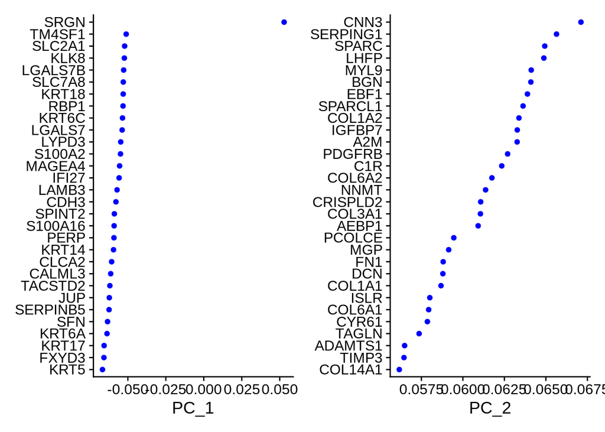

```r
VizDimLoadings(hnsccScaled, dims=1:2, reduction="pca")
```

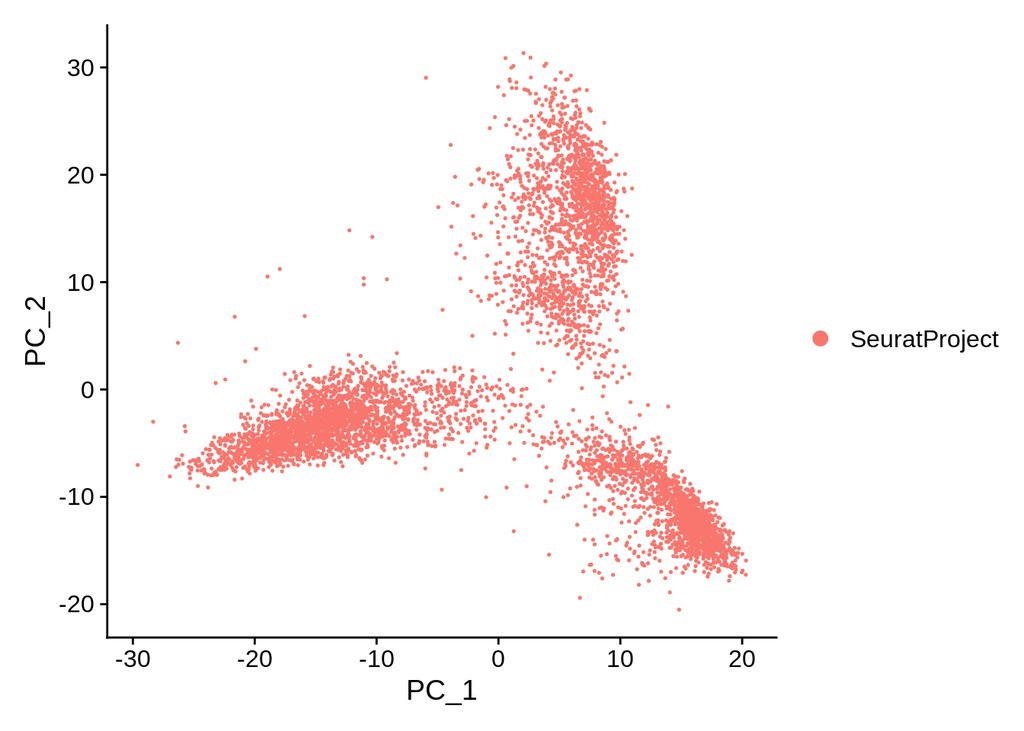

```r
DimPlot(hnsccScaled, reduction="pca")
```

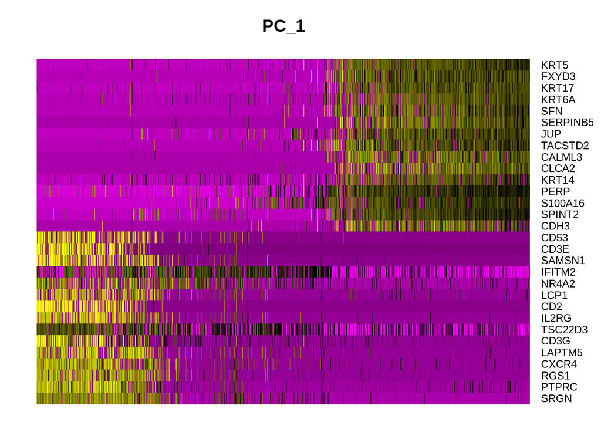

```r
DimHeatmap(hnsccScaled, dims=1,balanced=TRUE)
```

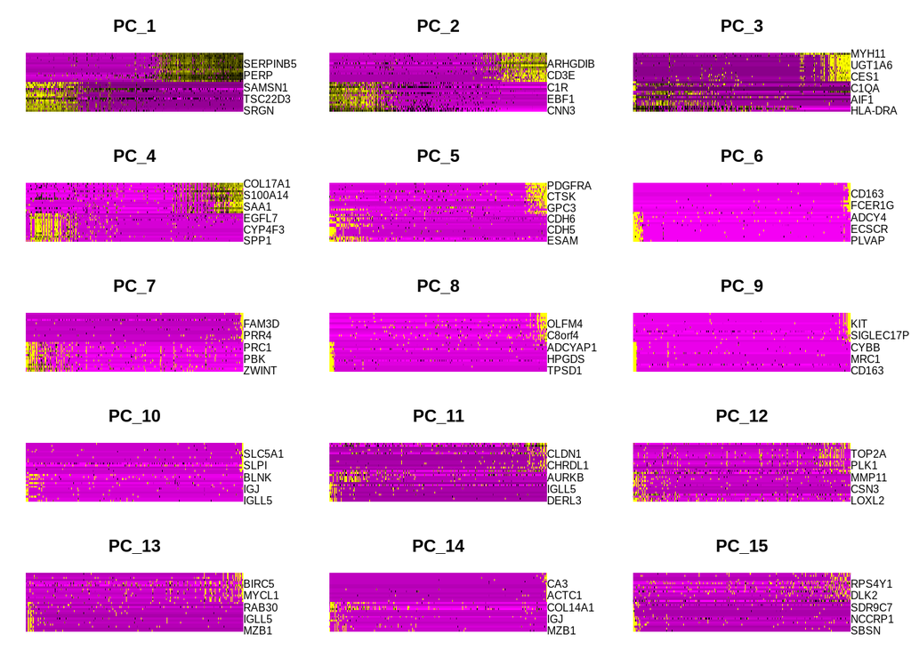

```r
DimHeatmap(hnsccScaled, dims=1:15,balanced=TRUE)
```

```r
#Determine the dimensionality of the dataset
#non si riesce a fare (ucciso)
#hnsccScaled <- JackStraw (hnsccScaled, num.replicate = 100)
#hnsccScaled <- ScoreJackStraw (hnsccScaled, dims = 1:20)
#
#JackStrawPlot(hnsccScaled, dims = 1:15)
```

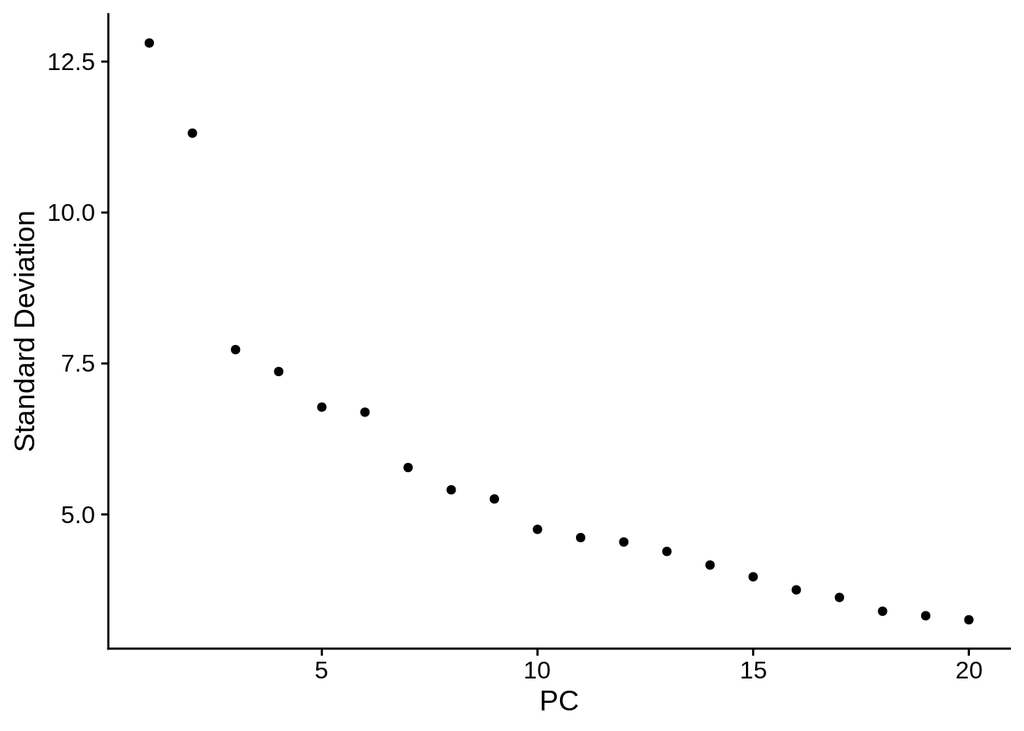

```r
ElbowPlot(hnsccScaled)
```

##Clustering We then start with the clustering

```r
#clustering
hnsccScaled <- FindNeighbors(hnsccScaled, dims = 1:10)
hnsccScaled <- FindClusters(hnsccScaled, resolution = 0.5)
```

```
## Modularity Optimizer version 1.3.0 by Ludo Waltman and Nees Jan van Eck
##
## Number of nodes: 5902
## Number of edges: 182771
##
## Running Louvain algorithm...
## Maximum modularity in 10 random starts: 0.9326
## Number of communities: 15
## Elapsed time: 0 seconds
```

```r
head(Idents(hnsccScaled),5)
```

```
## V2 V3 V4 V5 V6
##  2  2  9  2  9
## Levels: 0 1 2 3 4 5 6 7 8 9 10 11 12 13 14
```

```r
#run umap
hnsccScaled <- RunUMAP (hnsccScaled, dims=1:10)
```

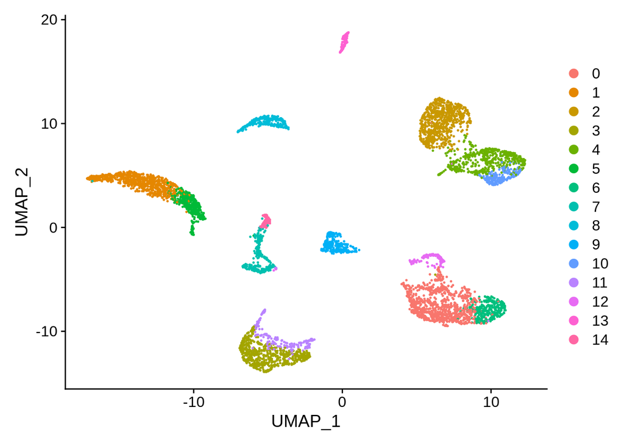

```r
DimPlot(hnsccScaled, reduction="umap")
```

Save the RDS

```r
saveRDS(hnsccScaled, file= '/home/ressf/Documenti/RessBachelorsThesisCode/Downstream_analysis/HNSCC/hnsccScaled.rds')
```

Find the markers of the clusters

```r
cluster1.markers <- FindMarkers(hnsccScaled, ident.1 = 1, min.pct = 0.25)
head(cluster1.markers, n = 5)
```

```
##       p_val avg_logFC pct.1 pct.2 p_val_adj
## CXCR4     0  1.812151 0.907 0.189         0
## PTPRC     0  1.712581 0.946 0.245         0
## CD2       0  1.664335 0.709 0.092         0
## CD3E      0  1.590718 0.667 0.084         0
## LCK       0  1.571464 0.605 0.089         0
```

```r
cluster5.markers <- FindMarkers(hnsccScaled, ident.1 = 5, ident.2 = c(0, 3), min.pct = 0.25)
head(cluster5.markers, n = 5)
```

```
##       p_val avg_logFC pct.1 pct.2 p_val_adj
## RGS1      0  2.475841 0.948 0.032         0
## SRGN      0  2.351315 0.993 0.030         0
## CD2       0  2.285403 0.958 0.006         0
## CD3D      0  2.242232 0.896 0.004         0
## IL2RG     0  2.232197 0.918 0.016         0
```

Find markers for every cluster

```r
# find markers for every cluster compared to all remaining cells, report only the positive ones
hnsccScaled.markers <- FindAllMarkers(hnsccScaled, only.pos = TRUE, min.pct = 0.25, logfc.threshold = 0.25, )
hnsccScaled.markers %>% group_by(cluster) %>% top_n(n = 2, wt = avg_logFC)
```

```
## # A tibble: 30 x 7
## # Groups:   cluster [15]
##        p_val avg_logFC pct.1 pct.2 p_val_adj cluster gene
##        <dbl>     <dbl> <dbl> <dbl>     <dbl> <fct>   <chr>
##  1 0.             1.39 0.981 0.229 0.        0       S100A2
##  2 0.             1.35 0.729 0.109 0.        0       S100A9
##  3 0.             1.81 0.907 0.189 0.        1       CXCR4
##  4 0.             1.71 0.946 0.245 0.        1       PTPRC
##  5 0.             2.13 0.933 0.134 0.        2       ACTA2
##  6 0.             1.99 0.958 0.165 0.        2       TAGLN
##  7 0.             1.63 1     0.151 0.        3       EPCAM
##  8 0.             1.63 0.933 0.024 0.        3       GSTA1
##  9 0.             1.51 0.807 0.159 0.        4       COL3A1
## 10 1.78e-267      1.56 0.735 0.167 4.22e-263 4       LUM
## # … with 20 more rows
```

Print the table with # cluster and # cells:

```r
table(Idents(hnsccScaled))
```

```
##
##   0   1   2   3   4   5   6   7   8   9  10  11  12  13  14
## 956 784 713 626 544 403 313 279 272 268 210 196 128 122  88
```

Create the plot for every cluster: Cluster 0:

```r
plotmarker0<- FeaturePlot(hnsccScaled, features=c("S100A2", "S100A9", "KRT16", "ANXA8L1", "KRT14", "S100A8", "GJB2", "COL17A1", "KRT6A", "LGALS7"))
```

Cluster 1:

```r
plotmarker1<- FeaturePlot(hnsccScaled, features= c("CXCR4", "PTPRC", "CD2", "CD3E", "LCK", "CD3D", "FYN", "SRGN", "GZMK", "CCR7"))
```

Cluster 2:

```r
plotmarker2<-FeaturePlot(hnsccScaled, features=c("ACTA2", "TAGLN", "MUSTN1", "PLN", "A2M", "SPARCL1", "MYL9", "ADAMTS1", "MYH11", "FHL5"))
```

Cluster 3:

```r
plotmarker3<-FeaturePlot(hnsccScaled, features=c("EPCAM", "GSTA1", "GSTM1", "CES1", "SPP1", "FGFBP2", "OSGIN1", "ALDH3A1", "GPX2", "UGT1A6"))
```

Cluster 4:

```r
plotmarker4<-FeaturePlot(hnsccScaled, features=c("COL3A1", "COL6A3", "RARRES2", "MXRA8", "COL1A2", "LUM", "DCN", "CTSK", "COL1A1", "MMP2"))
```

Cluster 5:

```r
plotmarker5<-FeaturePlot(hnsccScaled,features=c("CXCR6", "CD3D", "SIRPG", "CD2", "PRF1", "TIGIT", "ICOS", "LCK", "GNLY", "GZMB"))
```

Cluster 6:

```r
plotmarker6<-FeaturePlot(hnsccScaled,features=c("CCNB1", "GJB6", "TK1", "PLEK2", "CDC20", "GJB2", "COL17A1", "FGFBP1", "S100A9", "S100A2"))
```

Cluster 7:

```r
plotmarker7<-FeaturePlot(hnsccScaled,features=c("ELK2AP", "MZB1", "DERL3", "CD79A", "IGLL5", "IGJ", "NCF1", "BLNK", "SLAMF7", "FKBP11"))
```

Cluster 8:

```r
plotmarker8<-FeaturePlot(hnsccScaled,features=c("PLVAP", "RAMP3", "RNASE1", "CLEC14A", "DARC", "AQP1", "VWF", "CDH5", "CLDN5", "HYAL2"))
```

Cluster 9:

```r
plotmarker9<-FeaturePlot(hnsccScaled,features=c("CSN3", "FDCSP", "UBD", "TRIT1", "MGST1", "MYCL1", "ODAM", "SULT1E1", "CLDN1", "KRT19"))
```

Cluster 10:

```r
plotmarker10<-FeaturePlot(hnsccScaled,features=c("APOD", "SFRP2", "DPT", "PODN", "ABCA8", "FBLN2", "MFAP4", "C3", "CXCL12", "CFD"))
```

Cluster 11:

```r
plotmarker11<-FeaturePlot(hnsccScaled,features=c("GPX2", "AKR1C2", "AKR1C1", "ALDH3A1", "ADH7", "IPMK", "AKR1C3", "SAMD12", "SUZ12P1", "CYP4F11"))
```

Cluster 12:

```r
plotmarker12<-FeaturePlot(hnsccScaled,features=c("AZGP1", "ZG16B", "CRISP3", "TCN1", "PIP", "STATH", "MUC7", "PRR4", "SLPI", "PIGR" ))
```

Cluster 13:

```r
plotmarker13<-FeaturePlot(hnsccScaled,features=c("TPSAB1", "TPSB2", "CPA3", "TPSD1", "HDC", "CTSG", "KIT", "HPGDS", "IL1RL1", "MS4A2"))
```

Cluster 14:

```r
plotmarker14<-FeaturePlot(hnsccScaled,features=c("C1QB", "AIF1", "C1QC", "MS4A6A", "C1QA", "FCER1G", "FCGR3A", "TYROBP", "IGSF6", "FCGR2A" ))
```

```r
new.cluster.ids <-c("Basal cells", "T helper cells","Ectoderm","Basal cells, maybe cancer basal cells", "Fibroblast", "T cells", "Basal cells in phase S/M", "B cells", "Endothelial cells", "Mesoderm cells", "Fibroblast", "Aorta Endothelial cell", "Airway epithelial cell", "mast cell + neutrophils", "gamma delta T cells")
```

We rename the clusters

```r
names(new.cluster.ids) <- levels(hnsccScaled)
hnsccScaled <- RenameIdents(hnsccScaled, new.cluster.ids)
```

We plot the clusters with the names with no legend:

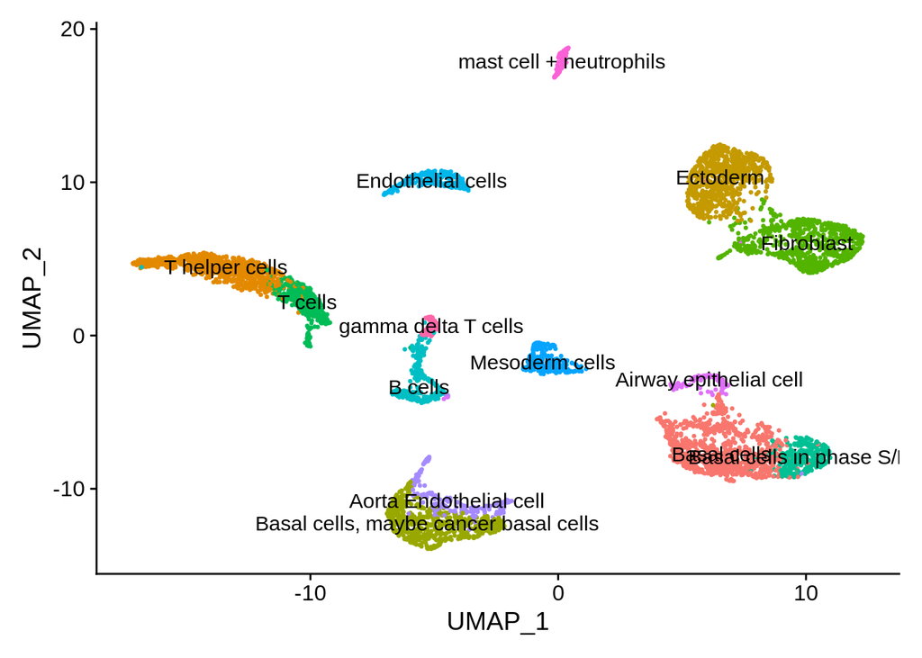

```r
DimPlot(hnsccScaled, reduction = "umap", label = TRUE, pt.size = 0.5) + NoLegend()
```

and with legend:

[output not shown]

We save the final object

```r
saveRDS(hnsccScaled, file = "/home/ressf/Documenti/RessBachelorsThesisCode/Downstream_analysis/HNSCC/hnscc_final.rds")
```